# Consumer Lending Risk – End-to-End Pipeline

Production-style credit default prediction API demonstrating robust ML engineering patterns for credit risk modelling. Built with LightGBM/XGBoost, FastAPI, and comprehensive automated testing.

| Component | Detail |
| --- | --- |
| **Backends** | LightGBM / XGBoost (configurable) |
| **Calibration** | `CalibratedClassifierCV` (Platt scaling) |
| **Imbalance** | `class_weight="balanced"` / `scale_pos_weight` |
| **Serving** | FastAPI with Pydantic feature-contract enforcement |
| **Testing** | 10 pytest tests (unit, integration, API) |
| **Deployment** | Docker, GitHub Actions CI |

> **Dataset:** [Kaggle Loan Default Dataset](https://www.kaggle.com/datasets/yasserh/loan-default-dataset) — place `Loan_Default.csv` in `data/raw/`.

**Dataset context:** The Loan Default dataset contains 148,670 mortgage applications with 34 features covering borrower demographics (age, gender, income), loan characteristics (amount, term, type), credit profile (credit score, credit type), and property details. The prediction target is binary loan default. With a ~25% default rate, this is a moderately imbalanced classification problem typical of real-world consumer lending portfolios.

> 📋 **[Back to README](https://github.com/agbajames/consumer-lending-risk-api)**

## 1. Setup & Configuration

```python
# file: pipeline/setup.py (or first notebook cell)

from __future__ import annotations

import warnings
warnings.filterwarnings(
    "ignore",
    message=".*str.*dtypes are inc.*",
    category=UserWarning,
)
warnings.filterwarnings(
    "ignore",
    message=".*X does not have valid feature names.*",
    category=UserWarning,
    module="sklearn",
)

import json
import importlib.util
import logging
import subprocess
import sys
import time
from pathlib import Path

AUTO_INSTALL = True  # set False if you never want runtime installs

_REQUIRED = {
    "numpy": "numpy",
    "pandas": "pandas",
    "matplotlib": "matplotlib",
    "sklearn": "scikit-learn",
    "lightgbm": "lightgbm",
    "xgboost": "xgboost",
    "jinja2": "jinja2",
    "joblib": "joblib",
    "isort": "isort",
}


def _missing_packages(required: dict[str, str]) -> list[str]:
    missing: list[str] = []
    for import_name, pip_name in required.items():
        if importlib.util.find_spec(import_name) is None:
            missing.append(pip_name)
    return missing


def ensure_dependencies(auto_install: bool = True) -> None:
    """
    Ensures this kernel/interpreter has required packages.
    Installs missing deps using the same interpreter as the current kernel.
    """
    missing = _missing_packages(_REQUIRED)
    if not missing:
        return

    msg = (
        "Missing packages for this kernel/interpreter:\n"
        f"  - {', '.join(missing)}\n"
        f"Kernel Python: {sys.executable}\n"
    )
    if not auto_install:
        raise ModuleNotFoundError(
            msg
            + "Install them into this interpreter, then restart the kernel."
        )

    result = subprocess.run(
        [sys.executable, "-m", "pip", "install", "-U", *missing],
        stdout=subprocess.DEVNULL,
        stderr=subprocess.DEVNULL,
    )


ensure_dependencies(AUTO_INSTALL)

import numpy as np
import pandas as pd
import matplotlib.pyplot as plt

from sklearn.model_selection import train_test_split
from sklearn.metrics import (
    roc_auc_score,
    average_precision_score,
    brier_score_loss,
    f1_score,
    precision_score,
    recall_score,
    roc_curve,
    precision_recall_curve,
    confusion_matrix,
)
from sklearn.calibration import calibration_curve, CalibratedClassifierCV
from sklearn.compose import ColumnTransformer
from sklearn.pipeline import Pipeline
from sklearn.preprocessing import OneHotEncoder
from sklearn.impute import SimpleImputer

from lightgbm import LGBMClassifier
from xgboost import XGBClassifier
import joblib

logging.basicConfig(level=logging.INFO, format="%(levelname)s | %(message)s")
logger = logging.getLogger(__name__)

plt.rcParams.update(
    {
        "figure.facecolor": "white",
        "axes.facecolor": "white",
        "axes.grid": True,
        "grid.alpha": 0.3,
        "axes.spines.top": False,
        "axes.spines.right": False,
        "font.size": 11,
    }
)

PALETTE = {
    "lgb": "#2196F3",
    "xgb": "#FF9800",
    "cal": "#4CAF50",
    "ref": "#9E9E9E",

    "red": "#E53935",
}

print(
    "Setup complete ✓",
    f"(python={sys.version.split()[0]}, exe={Path(sys.executable).name}, numpy={np.__version__}, pandas={pd.__version__})",
)
```

```
Setup complete ✓ (python=3.11.13, exe=python3.11, numpy=2.4.3, pandas=3.0.1)
```

## 2. Configuration

```python
# ── Paths ──
BASE_DIR = Path(".")
DATA_DIR = BASE_DIR / "data"
RAW_DATA = DATA_DIR / "raw" / "Loan_Default.csv"
PROCESSED_DIR = DATA_DIR / "processed"
PROCESSED_TRAIN = PROCESSED_DIR / "train.csv"
PROCESSED_TEST = PROCESSED_DIR / "test.csv"
ARTIFACTS_DIR = BASE_DIR / "artifacts"
PIPELINE_PATH = ARTIFACTS_DIR / "model.joblib"
METADATA_PATH = ARTIFACTS_DIR / "metadata.json"

# ── Modelling ──
TARGET_COLUMN = "Status"
TEST_SIZE = 0.2
RANDOM_STATE = 42
DEFAULT_THRESHOLD = 0.5

# ── Cleaning ──
DROP_COLS = ["ID"]
RENAME_MAP = {"co-applicant_credit_type": "co_applicant_credit_type"}

# Post-origination columns whose missingness is a near-perfect target proxy
LEAKY_COLS = [
    "rate_of_interest",
    "Interest_rate_spread",
    "Upfront_charges",
    "property_value",
    "LTV",
]

ARTIFACTS_DIR.mkdir(parents=True, exist_ok=True)
PROCESSED_DIR.mkdir(parents=True, exist_ok=True)

print(f"Raw data path : {RAW_DATA}")
print(f"Artifacts path: {ARTIFACTS_DIR}")
```

```
Raw data path : data/raw/Loan_Default.csv
Artifacts path: artifacts
```

## 3. Data Loading & Initial Cleaning

Initial cleaning:

- Rename `co-applicant_credit_type` → `co_applicant_credit_type` (Python-safe identifier)
- Drop `ID` column (no predictive value)
- Drop rows with missing target

Imputation is **not** done here — it is handled exclusively by the sklearn pipeline to prevent train → test leakage.

```python
df_raw = pd.read_csv(RAW_DATA)
print(f"Raw shape: {df_raw.shape}")
df_raw.head()
```

```
Raw shape: (148670, 34)
```

|  | ID | year | loan_limit | Gender | approv_in_adv | loan_type | loan_purpose | Credit_Worthiness | open_credit | business_or_commercial | ... | credit_type | Credit_Score | co-applicant_credit_type | age | submission_of_application | LTV | Region | Security_Type | Status | dtir1 |
| --- | --- | --- | --- | --- | --- | --- | --- | --- | --- | --- | --- | --- | --- | --- | --- | --- | --- | --- | --- | --- | --- |
| 0 | 24890 | 2019 | cf | Sex Not Available | nopre | type1 | p1 | l1 | nopc | nob/c | ... | EXP | 758 | CIB | 25-34 | to_inst | 98.728814 | south | direct | 1 | 45.0 |
| 1 | 24891 | 2019 | cf | Male | nopre | type2 | p1 | l1 | nopc | b/c | ... | EQUI | 552 | EXP | 55-64 | to_inst | NaN | North | direct | 1 | NaN |
| 2 | 24892 | 2019 | cf | Male | pre | type1 | p1 | l1 | nopc | nob/c | ... | EXP | 834 | CIB | 35-44 | to_inst | 80.019685 | south | direct | 0 | 46.0 |
| 3 | 24893 | 2019 | cf | Male | nopre | type1 | p4 | l1 | nopc | nob/c | ... | EXP | 587 | CIB | 45-54 | not_inst | 69.376900 | North | direct | 0 | 42.0 |
| 4 | 24894 | 2019 | cf | Joint | pre | type1 | p1 | l1 | nopc | nob/c | ... | CRIF | 602 | EXP | 25-34 | not_inst | 91.886544 | North | direct | 0 | 39.0 |

5 rows × 34 columns

```python
def basic_clean(df, *, drop_leaky=False):
    """Clean without imputing. Optionally drop leaky columns."""
    df = df.copy()
    df = df.rename(columns=RENAME_MAP)
    for c in DROP_COLS:
        if c in df.columns:
            df = df.drop(columns=[c])
    if drop_leaky:
        leaky_present = [c for c in LEAKY_COLS if c in df.columns]
        df = df.drop(columns=leaky_present)
        logger.info("Dropped %d leaky columns: %s", len(leaky_present), leaky_present)
    df = df.dropna(subset=[TARGET_COLUMN])
    return df

# Clean without dropping leaky columns yet — we'll analyse them first
df_all = basic_clean(df_raw, drop_leaky=False)
print(f"Cleaned shape (all features): {df_all.shape}")
print(f"Target distribution:\n{df_all[TARGET_COLUMN].value_counts(normalize=True).round(4)}")
```

```
Cleaned shape (all features): (148670, 33)
Target distribution:
Status
0    0.7536
1    0.2464
Name: proportion, dtype: float64
```

## 4. Exploratory Data Analysis

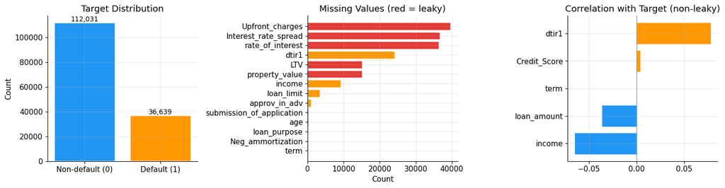

```python
fig, axes = plt.subplots(1, 3, figsize=(15, 4))

# 4a – Target distribution
counts = df_all[TARGET_COLUMN].value_counts()
bars = axes[0].bar(
    ["Non-default (0)", "Default (1)"],
    counts.values,
    color=[PALETTE["lgb"], PALETTE["xgb"]],
    edgecolor="white", linewidth=1.2,
)
axes[0].set_title("Target Distribution")
axes[0].set_ylabel("Count")
for bar, val in zip(bars, counts.values):
    axes[0].text(bar.get_x() + bar.get_width()/2, bar.get_height(),
                 f"{val:,}", ha="center", va="bottom", fontsize=10)

# 4b – Missing values (top 15)
miss = df_all.isna().sum().sort_values(ascending=False).head(15)
miss = miss[miss > 0]
if len(miss) > 0:
    colours = [PALETTE["red"] if idx in LEAKY_COLS else PALETTE["xgb"] for idx in miss.index]
    axes[1].barh(miss.index, miss.values, color=colours, edgecolor="white")
    axes[1].set_title("Missing Values (red = leaky)")
    axes[1].set_xlabel("Count")
    axes[1].invert_yaxis()
else:
    axes[1].text(0.5, 0.5, "No missing values", ha="center", va="center",
                 transform=axes[1].transAxes, fontsize=13)
    axes[1].set_title("Missing Values")

# 4c – Correlations of numeric features with target
numeric_cols = df_all.select_dtypes(include=["number"]).columns.drop(TARGET_COLUMN, errors="ignore")
sample_feats = [f for f in numeric_cols if f not in LEAKY_COLS][:8]
if sample_feats:
    corr = df_all[sample_feats + [TARGET_COLUMN]].corr()[TARGET_COLUMN].drop(TARGET_COLUMN).sort_values()
    axes[2].barh(corr.index, corr.values,
                 color=[PALETTE["xgb"] if v > 0 else PALETTE["lgb"] for v in corr.values],
                 edgecolor="white")
    axes[2].set_title("Correlation with Target (non-leaky)")
    axes[2].axvline(0, color="grey", linewidth=0.8)

plt.tight_layout()
plt.show()
```

```python
num_summary = df_all.describe().T
num_summary["missing"] = df_all.isna().sum()
num_summary["missing_%"] = (df_all.isna().sum() / len(df_all) * 100).round(2)
num_summary[["count", "mean", "std", "min", "max", "missing", "missing_%"]].head(15)
```

|  | count | mean | std | min | max | missing | missing_% |
| --- | --- | --- | --- | --- | --- | --- | --- |
| year | 148670.0 | 2019.000000 | 0.000000 | 2019.000000 | 2.019000e+03 | 0 | 0.00 |
| loan_amount | 148670.0 | 331117.743997 | 183909.310127 | 16500.000000 | 3.576500e+06 | 0 | 0.00 |
| rate_of_interest | 112231.0 | 4.045476 | 0.561391 | 0.000000 | 8.000000e+00 | 36439 | 24.51 |
| Interest_rate_spread | 112031.0 | 0.441656 | 0.513043 | -3.638000 | 3.357000e+00 | 36639 | 24.64 |
| Upfront_charges | 109028.0 | 3224.996127 | 3251.121510 | 0.000000 | 6.000000e+04 | 39642 | 26.66 |
| term | 148629.0 | 335.136582 | 58.409084 | 96.000000 | 3.600000e+02 | 41 | 0.03 |
| property_value | 133572.0 | 497893.465696 | 359935.315562 | 8000.000000 | 1.650800e+07 | 15098 | 10.16 |
| income | 139520.0 | 6957.338876 | 6496.586382 | 0.000000 | 5.785800e+05 | 9150 | 6.15 |
| Credit_Score | 148670.0 | 699.789103 | 115.875857 | 500.000000 | 9.000000e+02 | 0 | 0.00 |
| LTV | 133572.0 | 72.746457 | 39.967603 | 0.967478 | 7.831250e+03 | 15098 | 10.16 |
| Status | 148670.0 | 0.246445 | 0.430942 | 0.000000 | 1.000000e+00 | 0 | 0.00 |
| dtir1 | 124549.0 | 37.732932 | 10.545435 | 5.000000 | 6.100000e+01 | 24121 | 16.22 |

## 5. Leakage Analysis

A critical step for any lending dataset: checking whether feature **missingness patterns** leak the target. Post-origination fields (e.g. interest rate, upfront charges) are often populated only for funded, performing loans — meaning their absence is itself a near-perfect predictor of default.

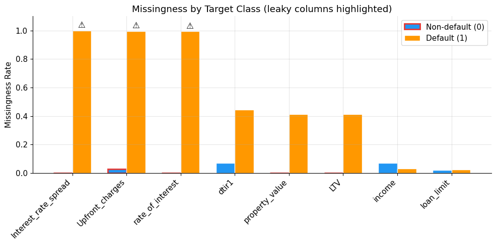

```
Missingness rates by class:
              column  miss_non_default  miss_default  leaky
Interest_rate_spread              0.0%        100.0%   True
     Upfront_charges              2.8%         99.6%   True
    rate_of_interest              0.0%         99.5%   True
               dtir1              7.0%         44.5%  False
      property_value              0.0%         41.2%   True
                 LTV              0.0%         41.2%   True
              income              7.1%          3.4%  False
          loan_limit              2.2%          2.4%  False
```

```python
# Compute missingness rate by target class
miss_by_class = []

for c in df_all.columns:
    if c == TARGET_COLUMN:
        continue
    miss_rate = df_all[c].isna().mean()
    if miss_rate < 0.01:
        continue
    m0 = df_all.loc[df_all[TARGET_COLUMN] == 0, c].isna().mean()
    m1 = df_all.loc[df_all[TARGET_COLUMN] == 1, c].isna().mean()
    miss_by_class.append({"column": c, "miss_non_default": m0, "miss_default": m1})

leak_df = pd.DataFrame(miss_by_class).sort_values("miss_default", ascending=False)
leak_df["leaky"] = leak_df["column"].isin(LEAKY_COLS)

# Visualise
fig, ax = plt.subplots(figsize=(10, 5))
x = np.arange(len(leak_df))
w = 0.35

bars0 = ax.bar(x - w/2, leak_df["miss_non_default"], w, label="Non-default (0)",
               color=PALETTE["lgb"], edgecolor="white")
bars1 = ax.bar(x + w/2, leak_df["miss_default"], w, label="Default (1)",
               color=PALETTE["xgb"], edgecolor="white")

# Highlight leaky columns
for i, row in enumerate(leak_df.itertuples()):
    if row.leaky:
        ax.get_children()[i].set_edgecolor(PALETTE["red"])
        ax.get_children()[i].set_linewidth(2)

ax.set_xticks(x)
ax.set_xticklabels(leak_df["column"], rotation=45, ha="right")
ax.set_ylabel("Missingness Rate")
ax.set_title("Missingness by Target Class (leaky columns highlighted)")
ax.legend()
ax.set_ylim(0, 1.1)

for i, row in enumerate(leak_df.itertuples()):
    if row.miss_default > 0.5:
        ax.annotate("⚠️", (i + w/2, row.miss_default + 0.02), ha="center", fontsize=12)

plt.tight_layout()
plt.show()

print("\nMissingness rates by class:")
print(leak_df.to_string(index=False, float_format="{:.1%}".format))
```

```python
# Demonstrate the impact: train WITH leaky columns
X_demo = df_all.drop(columns=[TARGET_COLUMN])
y_demo = df_all[TARGET_COLUMN].astype(int)
X_tr_d, X_te_d, y_tr_d, y_te_d = train_test_split(
    X_demo, y_demo, test_size=0.2, random_state=RANDOM_STATE, stratify=y_demo
)

# LightGBM handles NaN natively via categorical encoding
for c in X_tr_d.select_dtypes(include=["object", "str"]).columns:
    X_tr_d[c] = X_tr_d[c].astype("category")
    X_te_d[c] = X_te_d[c].astype("category")

clf_leak = LGBMClassifier(n_estimators=100, random_state=RANDOM_STATE, verbose=-1)
clf_leak.fit(X_tr_d, y_tr_d)
auc_leak = roc_auc_score(y_te_d, clf_leak.predict_proba(X_te_d)[:, 1])

# Train WITHOUT leaky columns
X_clean = df_all.drop(columns=[TARGET_COLUMN] + LEAKY_COLS)
X_tr_c, X_te_c, y_tr_c, y_te_c = train_test_split(
    X_clean, y_demo, test_size=0.2, random_state=RANDOM_STATE, stratify=y_demo
)

for c in X_tr_c.select_dtypes(include=["object", "str"]).columns:
    X_tr_c[c] = X_tr_c[c].astype("category")
    X_te_c[c] = X_te_c[c].astype("category")

clf_clean = LGBMClassifier(n_estimators=100, random_state=RANDOM_STATE, verbose=-1)
clf_clean.fit(X_tr_c, y_tr_c)
auc_clean = roc_auc_score(y_te_c, clf_clean.predict_proba(X_te_c)[:, 1])

print(f"ROC-AUC WITH leaky columns:    {auc_leak:.4f}  ← missingness = free answer")
print(f"ROC-AUC WITHOUT leaky columns: {auc_clean:.4f}  ← genuine signal only")
print(f"\nDropping {len(LEAKY_COLS)} leaky columns for all subsequent analysis.")
```

```
ROC-AUC WITH leaky columns:    1.0000  ← missingness = free answer
ROC-AUC WITHOUT leaky columns: 0.8834  ← genuine signal only

Dropping 5 leaky columns for all subsequent analysis.
```

## 6. Train / Test Split (Clean Data)

With the leaky columns removed, we create a stratified 80/20 split.

```python
df = basic_clean(df_raw, drop_leaky=True)
print(f"Clean shape: {df.shape}")

X = df.drop(columns=[TARGET_COLUMN])
y = df[TARGET_COLUMN].astype(int)

X_train, X_test, y_train, y_test = train_test_split(
    X, y, test_size=TEST_SIZE, random_state=RANDOM_STATE, stratify=y,
)

# Save to disk for API reproducibility
train_out = X_train.copy(); train_out[TARGET_COLUMN] = y_train
test_out = X_test.copy();   test_out[TARGET_COLUMN] = y_test
train_out.to_csv(PROCESSED_TRAIN, index=False)
test_out.to_csv(PROCESSED_TEST, index=False)

print(f"Train: {X_train.shape[0]:,} rows | Test: {X_test.shape[0]:,} rows")
print(f"Train default rate: {y_train.mean():.4f}")
print(f"Test  default rate: {y_test.mean():.4f}")
```

```
INFO | Dropped 5 leaky columns: ['rate_of_interest', 'Interest_rate_spread', 'Upfront_charges', 'property_value', 'LTV']
```

```
Clean shape: (148670, 28)
Train: 118,936 rows | Test: 29,734 rows
Train default rate: 0.2464
Test  default rate: 0.2465
```

## 7. Pipeline Construction

All preprocessing lives inside `.fit()` / `.transform()`, ensuring imputation statistics are learned only from training data.

```
ColumnTransformer
├── num → SimpleImputer(median)
└── cat → SimpleImputer(mode) → OneHotEncoder
↓
CalibratedClassifierCV(LGBMClassifier / XGBClassifier)
```

```python
from src.model import build_pipeline, split_feature_types

numeric, categorical = split_feature_types(X_train)
print(f"Numeric features:     {len(numeric)}")
print(f"Categorical features: {len(categorical)}")
```

```
Numeric features:     6
Categorical features: 21
```

## 8. Training (Both Backends)

```python
results = {}

for backend in ["lightgbm", "xgboost"]:
    logger.info("Training %s...", backend)
    t0 = time.time()

    pipe = build_pipeline(numeric, categorical, backend=backend, y=y_train, calibration_cv=5)
    pipe.fit(X_train, y_train)

    elapsed = time.time() - t0
    proba = pipe.predict_proba(X_test)[:, 1]
    pred = (proba >= DEFAULT_THRESHOLD).astype(int)

    metrics = {
        "roc_auc": roc_auc_score(y_test, proba),
        "pr_auc": average_precision_score(y_test, proba),
        "brier": brier_score_loss(y_test, proba),
        "f1": f1_score(y_test, pred),
        "precision": precision_score(y_test, pred, zero_division=0),
        "recall": recall_score(y_test, pred, zero_division=0),
        "train_time_s": round(elapsed, 1),
    }

    results[backend] = {"pipeline": pipe, "proba": proba, "pred": pred, "metrics": metrics}
    logger.info("%s done in %.1fs  |  ROC-AUC=%.4f  PR-AUC=%.4f  Brier=%.4f",
                backend, elapsed, metrics["roc_auc"], metrics["pr_auc"], metrics["brier"])

print()
```

```
INFO | Training lightgbm...
INFO | lightgbm done in 15.6s  |  ROC-AUC=0.8827  PR-AUC=0.8229  Brier=0.0913
INFO | Training xgboost...
INFO | xgboost done in 24.8s  |  ROC-AUC=0.8821  PR-AUC=0.8229  Brier=0.0913
```

```python
metrics_df = pd.DataFrame({k: v["metrics"] for k, v in results.items()}).T
metrics_df.index.name = "backend"
metrics_df.style.format("{:.4f}").background_gradient(cmap="Blues", axis=0)
```

| backend | roc_auc | pr_auc | brier | f1 | precision | recall | train_time_s |
| --- | --- | --- | --- | --- | --- | --- | --- |
| lightgbm | 0.8827 | 0.8229 | 0.0913 | 0.7311 | 0.8607 | 0.6355 | 15.6000 |
| xgboost | 0.8821 | 0.8229 | 0.0913 | 0.7308 | 0.8593 | 0.6358 | 24.8000 |

## 9. Evaluation

### 9a. ROC & Precision–Recall Curves

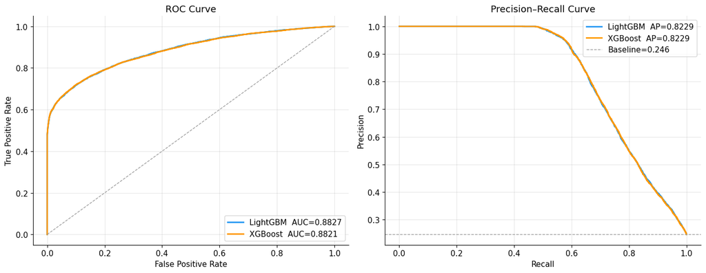

```python
fig, axes = plt.subplots(1, 2, figsize=(14, 5.5))
label_map = {"lightgbm": "LightGBM", "xgboost": "XGBoost"}
color_map = {"lightgbm": PALETTE["lgb"], "xgboost": PALETTE["xgb"]}

for backend, res in results.items():
    fpr, tpr, _ = roc_curve(y_test, res["proba"])
    auc = res["metrics"]["roc_auc"]
    axes[0].plot(fpr, tpr, label=f'{label_map[backend]}  AUC={auc:.4f}',
                 color=color_map[backend], linewidth=2)
axes[0].plot([0, 1], [0, 1], "--", color=PALETTE["ref"], linewidth=1)
axes[0].set(xlabel="False Positive Rate", ylabel="True Positive Rate", title="ROC Curve")
axes[0].legend(loc="lower right")

for backend, res in results.items():
    prec, rec, _ = precision_recall_curve(y_test, res["proba"])
    ap = res["metrics"]["pr_auc"]
    axes[1].plot(rec, prec, label=f'{label_map[backend]}  AP={ap:.4f}',
                 color=color_map[backend], linewidth=2)
baseline = y_test.mean()
axes[1].axhline(baseline, linestyle="--", color=PALETTE["ref"], linewidth=1, label=f"Baseline={baseline:.3f}")
axes[1].set(xlabel="Recall", ylabel="Precision", title="Precision–Recall Curve")
axes[1].legend(loc="upper right")

plt.tight_layout()
plt.show()
```

### 9b. Calibration Curves

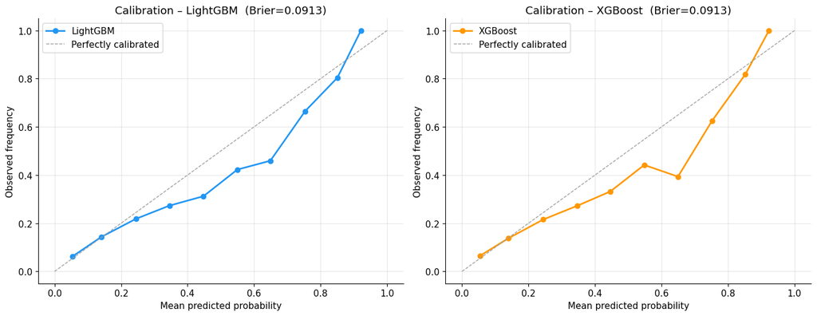

```python
fig, axes = plt.subplots(1, 2, figsize=(14, 5.5))

for i, (backend, res) in enumerate(results.items()):
    fraction_pos, mean_pred = calibration_curve(y_test, res["proba"], n_bins=10, strategy="uniform")
    axes[i].plot(mean_pred, fraction_pos, "o-", color=color_map[backend], linewidth=2,
                 markersize=6, label=label_map[backend])
    axes[i].plot([0, 1], [0, 1], "--", color=PALETTE["ref"], linewidth=1, label="Perfectly calibrated")
    axes[i].set(xlabel="Mean predicted probability", ylabel="Observed frequency",
                title=f"Calibration – {label_map[backend]}  (Brier={res['metrics']['brier']:.4f})")
    axes[i].legend(loc="upper left")

plt.tight_layout()
plt.show()
```

### 9c. Confusion Matrices

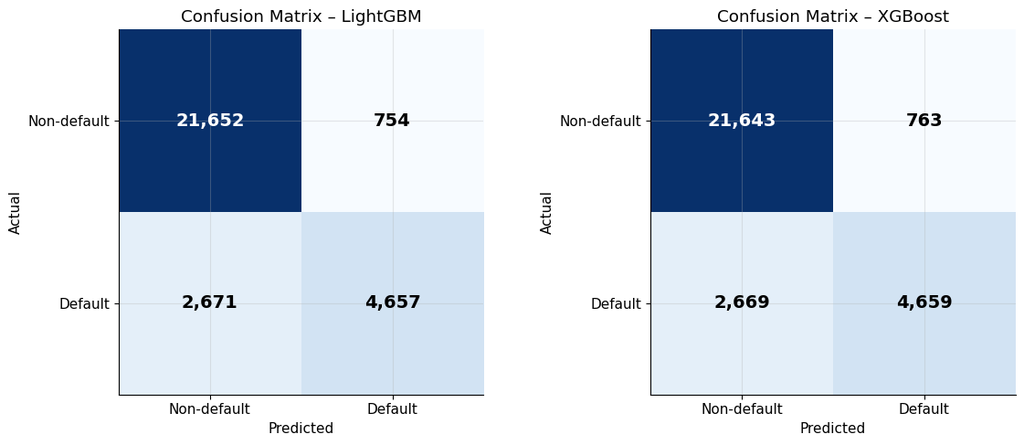

```python
fig, axes = plt.subplots(1, 2, figsize=(12, 5))

for i, (backend, res) in enumerate(results.items()):
    cm = confusion_matrix(y_test, res["pred"])
    im = axes[i].imshow(cm, cmap="Blues", aspect="equal")

    for row in range(2):
        for col in range(2):
            val = cm[row, col]
            colour = "white" if val > cm.max() / 2 else "black"
            axes[i].text(col, row, f"{val:,}", ha="center", va="center",
                         fontsize=14, fontweight="bold", color=colour)

    axes[i].set(xticks=[0, 1], yticks=[0, 1],
                xticklabels=["Non-default", "Default"],
                yticklabels=["Non-default", "Default"],
                xlabel="Predicted", ylabel="Actual",
                title=f"Confusion Matrix – {label_map[backend]}")

plt.tight_layout()
plt.show()
```

### 9d. Probability Distribution by Class

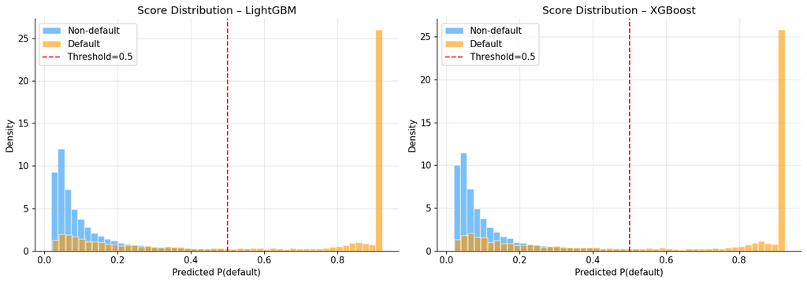

```python
fig, axes = plt.subplots(1, 2, figsize=(14, 5))

for i, (backend, res) in enumerate(results.items()):
    p0 = res["proba"][y_test == 0]
    p1 = res["proba"][y_test == 1]
    axes[i].hist(p0, bins=50, alpha=0.6, color=PALETTE["lgb"], label="Non-default", density=True, edgecolor="white")
    axes[i].hist(p1, bins=50, alpha=0.6, color=PALETTE["xgb"], label="Default", density=True, edgecolor="white")
    axes[i].axvline(DEFAULT_THRESHOLD, color="red", linestyle="--", linewidth=1.5, label=f"Threshold={DEFAULT_THRESHOLD}")
    axes[i].set(xlabel="Predicted P(default)", ylabel="Density",
                title=f"Score Distribution – {label_map[backend]}")
    axes[i].legend()

plt.tight_layout()
plt.show()
```

### 9e. Feature Importance (Top 20)

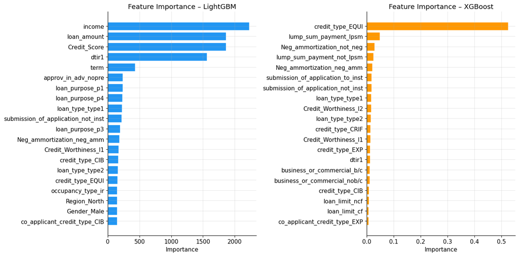

```python
fig, axes = plt.subplots(1, 2, figsize=(14, 7))

for i, (backend, res) in enumerate(results.items()):
    pipe = res["pipeline"]
    pre = pipe.named_steps["pre"]
    clf = pipe.named_steps["clf"]

    feature_names = [n.split("__", 1)[-1] for n in pre.get_feature_names_out()]

    importances = np.mean([
        cc.estimator.feature_importances_
        for cc in clf.calibrated_classifiers_
    ], axis=0)

    imp_df = pd.Series(importances, index=feature_names).sort_values(ascending=True).tail(20)
    axes[i].barh(imp_df.index, imp_df.values, color=color_map[backend], edgecolor="white")
    axes[i].set_title(f"Feature Importance – {label_map[backend]}")
    axes[i].set_xlabel("Importance")

plt.tight_layout()
plt.show()
```

## 10. Threshold Analysis

In production lending, the decision threshold is a business lever — not just 0.5. This section explores the F1 / precision / recall trade-off across thresholds.

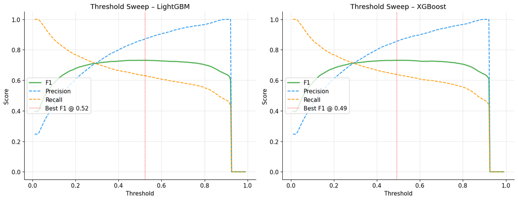

```python
fig, axes = plt.subplots(1, 2, figsize=(14, 5.5))

for i, (backend, res) in enumerate(results.items()):
    thresholds = np.linspace(0.01, 0.99, 200)
    f1s, precs, recs = [], [], []

    for t in thresholds:
        p = (res["proba"] >= t).astype(int)
        f1s.append(f1_score(y_test, p, zero_division=0))
        precs.append(precision_score(y_test, p, zero_division=0))
        recs.append(recall_score(y_test, p, zero_division=0))

    axes[i].plot(thresholds, f1s, label="F1", color=PALETTE["cal"], linewidth=2)
    axes[i].plot(thresholds, precs, label="Precision", color=PALETTE["lgb"], linewidth=1.5, linestyle="--")
    axes[i].plot(thresholds, recs, label="Recall", color=PALETTE["xgb"], linewidth=1.5, linestyle="--")

    best_t = thresholds[np.argmax(f1s)]
    axes[i].axvline(best_t, color="red", linestyle=":", linewidth=1, label=f"Best F1 @ {best_t:.2f}")
    axes[i].set(xlabel="Threshold", ylabel="Score", title=f"Threshold Sweep – {label_map[backend]}")
    axes[i].legend(loc="center left")

plt.tight_layout()
plt.show()
```

## 11. Save Model & Metadata

```python
best_backend = max(results, key=lambda b: results[b]["metrics"]["pr_auc"])
best = results[best_backend]

joblib.dump(best["pipeline"], PIPELINE_PATH)

metadata = {
    "trained_at": time.strftime("%Y-%m-%dT%H:%M:%SZ", time.gmtime()),
    "model_type": f"Calibrated({best_backend})",
    "backend": best_backend,
    "features": X_train.columns.tolist(),
    "numeric": numeric,
    "categorical": categorical,
    "threshold": DEFAULT_THRESHOLD,
    **{k: round(v, 6) for k, v in best["metrics"].items()},
}

with open(METADATA_PATH, "w") as f:
    json.dump(metadata, f, indent=2)

print(f"Saved pipeline  → {PIPELINE_PATH}")
print(f"Saved metadata  → {METADATA_PATH}")
print(f"Best backend    → {best_backend}")
print(f"\nMetadata:\n{json.dumps(metadata, indent=2)}")
```

```
Saved pipeline  → artifacts/model.joblib
Saved metadata  → artifacts/metadata.json
Best backend    → xgboost

Metadata:
{
  "trained_at": "2026-03-24T12:38:53Z",
  "model_type": "Calibrated(xgboost)",
  "backend": "xgboost",
  "features": [
    "year",
    "loan_limit",
    "Gender",
    "approv_in_adv",
    "loan_type",
    "loan_purpose",
    "Credit_Worthiness",
    "open_credit",
    "business_or_commercial",
    "loan_amount",
    "term",
    "Neg_ammortization",
    "interest_only",
    "lump_sum_payment",
    "construction_type",
    "occupancy_type",
    "Secured_by",
    "total_units",
    "income",
    "credit_type",
    "Credit_Score",
    "co_applicant_credit_type",
    "age",
    "submission_of_application",
    "Region",
    "Security_Type",
    "dtir1"
  ],
  "numeric": [
    "year",
```

[output cut: 23 more lines]

```
    "co_applicant_credit_type",
    "age",
    "submission_of_application",
    "Region",
    "Security_Type"
  ],
  "threshold": 0.5,
  "roc_auc": 0.882076,
  "pr_auc": 0.822938,
  "brier": 0.091336,
  "f1": 0.730824,
  "precision": 0.859277,
  "recall": 0.635781,
  "train_time_s": 24.8
}
```

## 12. API Smoke Test

Quick verification that the saved model loads and scores correctly via the same code path the FastAPI app uses.

```python
loaded_pipe = joblib.load(PIPELINE_PATH)
with open(METADATA_PATH) as f:
    loaded_meta = json.load(f)

sample = {
    "year": 2017, "loan_limit": "cf", "Gender": "Male", "approv_in_adv": "nopre",
    "loan_type": "type1", "loan_purpose": "p1", "Credit_Worthiness": "l1",
    "open_credit": "yes", "business_or_commercial": "no", "loan_amount": 150000.0,
    "term": 180.0, "Neg_ammortization": "no", "interest_only": "no",
    "lump_sum_payment": "no", "construction_type": "existing",
    "occupancy_type": "owner", "Secured_by": "home", "total_units": "1",
    "income": 6500.0, "credit_type": "CR1", "Credit_Score": 720.0,
    "co_applicant_credit_type": "Na", "age": "25-34",
    "submission_of_application": "to_inst", "Region": "south",
    "Security_Type": "type1", "dtir1": 28.0,
}

features = loaded_meta["features"]
X_single = pd.DataFrame([[sample[c] for c in features]], columns=features)
p1 = loaded_pipe.predict_proba(X_single)[0, 1]
threshold = loaded_meta["threshold"]

response = {
    "default_probability": round(float(p1), 6),
    "prediction": int(p1 >= threshold),
    "threshold": threshold,
    "model_info": {
        "model_type": loaded_meta["model_type"],
        "backend": loaded_meta["backend"],
        "trained_at": loaded_meta["trained_at"],
    },
}

print("POST /score response (simulated):")
print(json.dumps(response, indent=2))
```

```
POST /score response (simulated):
{
  "default_probability": 0.467872,
  "prediction": 0,
  "threshold": 0.5,
  "model_info": {
    "model_type": "Calibrated(xgboost)",
    "backend": "xgboost",
    "trained_at": "2026-03-24T12:38:53Z"
  }
}
```

## 13. Next Steps

- **Threshold optimisation** — Use Business-calibrated threshold selection balancing approval rate against expected loss (cost-sensitive decision boundary)
- **SHAP analysis** — Add feature-level explanations for individual predictions to support regulatory explainability requirements (ECOA/FCRA)
- **Richer feature engineering** — Derived risk ratios (loan-to-income, debt-to-income refinement) and application vintage effects
- **Monitoring** — PSI-based monitoring for input feature drift and calibration degradation over vintage cohorts

> 📋 **[Back to README](https://github.com/agbajames/consumer-lending-risk-api)**